**Machine Learning for Mechanical Engineering**  
**Homework 02 - Solution**  
**Due Tuesday, 04/07/20 09:30 AM**

TA : Taewan Kim  
Instructor: Prof. Seungchul Lee  
http://iai.postech.ac.kr/  
Industrial AI Lab at POSTECH

# Problem 1

Let $R = R(\theta)$ be a rotation matrix with a rotational angle of $\theta$ in $\mathbb{R}^n$.

(a) Prove that $$R^TR=I \;\text{in}\; \mathbb{R}^n$$

- Hint : Euclidian distances of vectors are preserved after a rotational operation. (i.e., $\lVert Rx \rVert = \lVert x \rVert$ for any $x \in \mathbb{R}^n$ )

(b) Prove that $$R^T(\theta) = R^{-1}(\theta) = R(-\theta)\;\text{in}\;\mathbb{R}^n$$
(c) Show that column vectors in $R$ are orthogonal in $\mathbb{R}^n$.

# Solution 1

(a) $\lVert Rx \rVert ^2 = (Rx)^T(Rx) = x^TR^TRx = \lVert x \rVert ^2 = x^Tx\,$ for any $x \implies R^TR = I$

(b) $R^TR = I \implies R^{-1} = R^T$

(c) $R^TR = I \implies r_i^T r_j = \delta_{ij} \\(\delta_{ij} = 0 \ \textrm{when} \ i \neq j)$

# Problem 2

Represent each of the following three functions $f: \mathbb{R}^2 \rightarrow \mathbb{R}^2$ as a matrix-vector product $f(x) = Ax$

(a) $f(x)$ is obtained by reflecting $x$ about the $x_1$ axis

(b) $f(x)$ is $x$ reflected about the $x_1$ axis, followed by a counter clockwise rotation of 30 degrees.

(c) $f(x)$ is $x$ rotated counterclockwise over 30 degrees, followed by a reflection about the $x_1$ axis

# Solution 2

(a)

$$f(x) = \begin{bmatrix} 1 & 0 \\ 0 & -1 \end{bmatrix}x$$

(b)

$$\begin{align*} R(\theta) &: \begin{bmatrix} \cos(\theta) & -\sin(\theta) \\ \sin(\theta) & \cos(\theta) \end{bmatrix}\ (\textrm{Rotation matrix}) \\\\ f(x) &= R\left(\frac{\pi}{6}\right)\begin{bmatrix}1&0\\0&-1\end{bmatrix} \end{align*}$$

(c)

$$f(x) = \begin{bmatrix} 1 & 0 \\ 0 & -1 \end{bmatrix}R\left(\frac{\pi}{6}\right)$$

# Problem 3

Let's assume a transformation $T : \mathbb{R}^2 \to \mathbb{R}^2$ projects an arbitrary vector onto a space spanned by $x = [1, 1]^T$.

Find the corresponding matrix $A$ by using

(a) Eigen decomposition (in other words, see how two eigenvectos are transformed by $T$) and

(b) Projection matrix.

# Solution 3

(a)

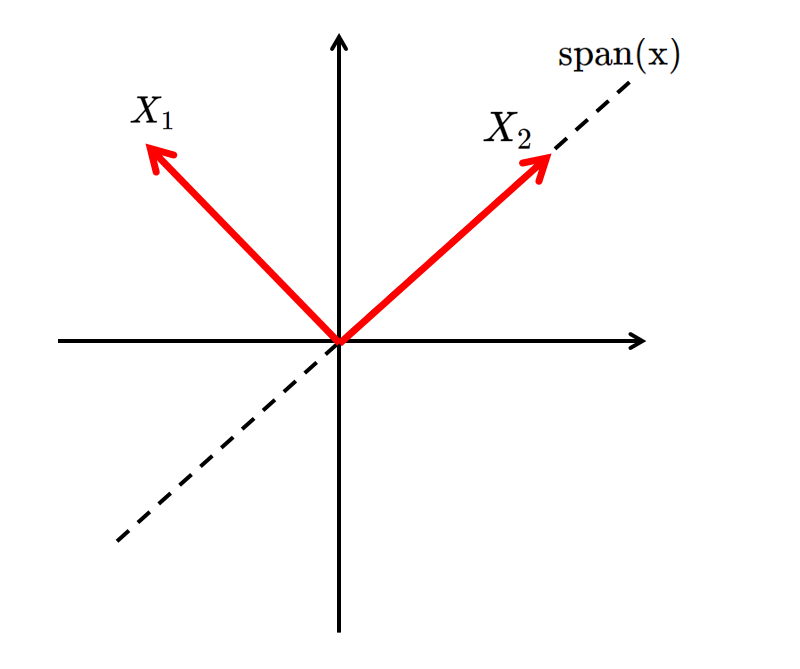

We have eigen pairs $(\lambda_1 , x_1), (\lambda_2 , x_2).$

$$ \begin{align*} (\lambda_1 , x_1) &= \left(0, \begin{bmatrix} -1 \\ 1 \end{bmatrix} \right) \\\\ (\lambda_2 , x_2) &= \left(1, \begin{bmatrix} 1 \\ 1 \end{bmatrix} \right) \end{align*} $$

# Problem 4

Let $x$ be a block vector with two vector elements, $x = \begin{bmatrix}a\\b\end{bmatrix}$ where $a$ and $b$ are vectors of size $n$ and $m$, respectively. Show that

$$\lVert x \rVert = \left(\lVert a \rVert^2 + \lVert b \rVert^2 \right)^{\frac{1}{2}} = \left\lVert \begin{bmatrix} \lVert a \rVert \\ \lVert b \rVert \end{bmatrix} \right\rVert$$

(Note that the norm on the right-hand side is of a 2-vector)

# Solution 4

$$ \begin{align*} \lVert x \rVert = \sqrt{x^{T} x} = \sqrt{\begin{bmatrix} a^T&b^T \end{bmatrix} \begin{bmatrix} a \\ b \end{bmatrix}} = \sqrt{a^T a + b^T b}\\\\ \text{Since} \ \ a^T a = \lVert a \rVert^2\ \, \text{and } \ b^T b = \lVert b \rVert^2\\ \\ \lVert x \rVert = \sqrt{\lVert a \rVert^2 + \lVert b \rVert^2} = \left\lVert \begin{bmatrix} \lVert a \rVert \\ \lVert b \rVert \end{bmatrix} \right\rVert \end{align*} $$

# Problem 5

There are system of equations

$$ \begin{align*} 83x + 12y + 10z &= 141 \\ -68x + 84y + 95z &= 145 \\ 32x + 23y + 43z &= 89 \end{align*} $$

(a) Write the equations in a matrix form. ($AX = B$)

(b) Does this system of equations have a solution?

- If yes, find the solution of system of equations
- If no, find the solution of system of equations that minimizes $\lVert AX-B \rVert $

# Solution 5

(a)

```python
import numpy as np
A = np.matrix([[83, 12, 10],[-68, 84, 95],[32, 23, 43]])
B = np.matrix([[141],[145],[89]])
```

(b)

```python
X_opt = A.I * B
print(X_opt)
```

```
[[ 1.26407393]
 [ 3.72735594]
 [-0.86464075]]
```

```python
X_opt =(A.T*A).I * A.T * B
print(X_opt)
```

```
[[ 1.26407393]
 [ 3.72735594]
 [-0.86464075]]
```

The system of equations have a uniqu solution.